# Autism All Grown Up

Ariel Balter

2024-06-06

# List of Figures

[figure not shown]

# 1 Mission

The mission of Autism All Grown Up (AAGU) is to empower autistic adults in Oregon by serving as a nexus that provides accessible information, resources, and services tailored to their unique needs. By bridging gaps in the existing infrastructure, we connect and interconnect the adult autistic community and their supporters, facilitate information exchange, and promote collaboration. This ensures that autistic individuals can access the support and opportunities they need to thrive, enhancing their well-being and independence throughout the state.

# 2 Executive Summary

## 2.1 Background

Dr. Ariel Balter, an experienced scientist and data analyst, was diagnosed with ADHD and ASD later in life and is raising a teenager with both diagnoses. His desire to understand these challenges led him to study the scientific and social aspects of neurodiversity. Recent changes driven by autistic self-advocates and researchers have reshaped our understanding of autism, revealing significant gaps in support for autistic adults. These changes have led to controversies and arguments that are still unfolding, emphasizing the evolving nature of the understanding of autism.

Through his personal journey and interactions with the local autistic community, Dr. Balter identified significant gaps in services, support, and understanding for autistic adults without intellectual disabilities. He was struck by the level of unmet need he heard from his peers—people with skills, education, and abilities but struggling for reasons related to autism. These personal experiences led Dr. Balter to found Autism All Grown Up (AAGU) to address these gaps.

## 2.2 Goals

The organization has four key objectives:

1. Facilitate connections and collaboration within the adult autistic community
2. Identify the unmet needs of autistic adults and report on the causes
3. Provide accurate, accessible, and up-to-date information and resources *for* autistic adults
4. Provide accurate, accessible, and up-to-date information and resources *about* autism and *about* the autistic community

## 2.3 Autism All Grown Up

Autism is all grown up, and it isn’t pretty. The phrase “All Grown Up” captures the bittersweet realization that often occurs when one encounters an individual they knew as a child, only to find that their preconceived notions no longer fit the adult standing before them.

For decades, autism was seen as a developmental challenge that primarily affected children. Outdated notions of what constitutes genuine autism have cause adults to be overlooked by many people. Because so little research has acknowledged the lives of adults with autism, we know close to nothing about what successful adult development looks like. Some existing research suggests that autistic adults face reduced life expectancy, increased risk for physical disability, and an earlier onset of age-related cognitive concerns[@Mason2021,@Mason2022]. Late-identified and never-identified autistic adults face unique challenges with respect to aging, and most of these “lost generations” [@Wright2015] have not yet even been counted.

## 2.4 The Nexus Approach

# 3 Autism in 2024

## 3.1 The New World of Autism

Recent advancements in our understanding of autism, largely driven by autistic self-advocates and researchers, have highlighted the need for a paradigm shift in understanding and supporting autistic individuals. Key findings include [@ASAN2009,@Weiss2023]:

- **The Autism Spectrum is not Linear**

  Autistic people aren’t “more” or “less” autistic so much as they are autistic in different ways.

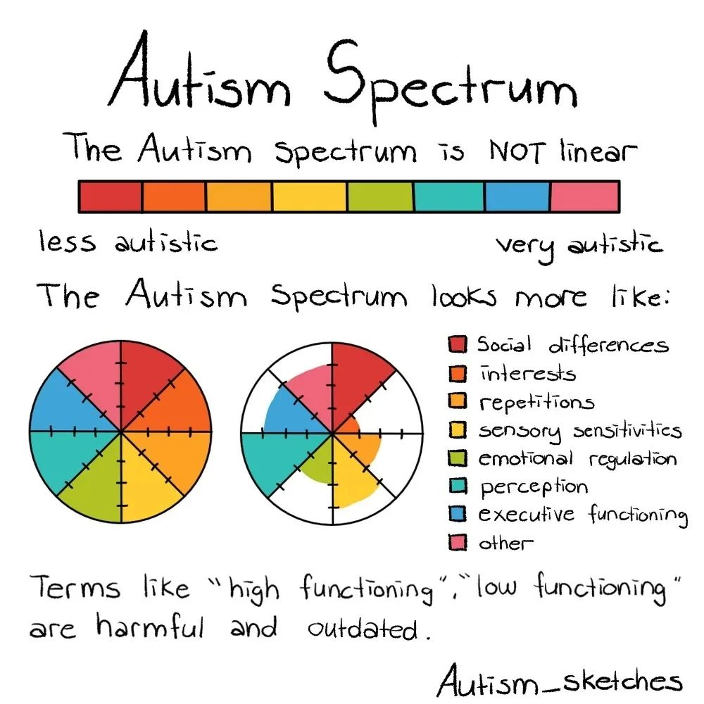

Figure 1. What the autism spectrum means.

- **Disability can be Contextual:**

  Most autistic individuals are not intellectually or physically disabled but face substantial challenges navigating society. Navigating society feels like being a left-handed person using right-handed scissors: difficult and unwieldy at best.
- **Misconceptions:**

  Science has refuted many harmful misconceptions about autism. Some autistic people have different accompanying conditions that can result in problems with body awareness, identifying their emotional state, or using speech. However, autistic people do not intrinsically lack feelings, empathy, social skills, or the ability to communicate.
- **Lifelong Condition:**

  Autism is a lifelong neurological difference, not a disorder to be cured. There are roughly the same percentage of autistic adults as children, but there are four times as many adults as children.
- **Neurodiversity & Neurodivergence:**

  The *neurodiversity paradigm* recognizes autism as a natural variation in human neurology. Individual people with cognitive styles that are significantly atypical are *neurodivergent*, and many have unmet needs.

## 3.2 Lost Generations of Autistic Adults

Autistic adults face unique challenges that are often overlooked, such as navigating social and employment environments not designed for neurodivergent individuals. Autistic adults without intellectual disabilities often face a lack of access to appropriate healthcare and support services.

Autistic adults perceived as having lower support needs face a conundrum. While they rarely qualify for existing systems of support, most face significant challenges that are often overlooked, dismissed, or disbelieved. Most autistic people will tell you that the hardest part about being autistic isn’t being autistic but navigating a neurotypical world that includes unconscious bias and ableism. Research backs this up, indicating that discrimination, not autism, is a significant barrier in the workplace.

Autistic adults face unique challenges that are often overlooked, such as navigating social and employment environments not designed for neurodivergent individuals. Key issues include:

- **Focus Gaps:** Research and services have predominantly focused on children leaving out adults, especially those without profound disabilities. We have failed, and continue to fail, to adequately study autistic life after high school when children lose many supports.

Despite these challenges, many autistic adults possess valuable skills, talents, and perspectives that society misses out on by not acknowledging their needs, hearing their voices, and making room for them at the table.

# 4 Autism All Grown Up (AAGU): A Nexus for Change

## 4.1 Origin

AAGU was born out of Dr. Balter’s desire to use his personal experiences and analytical skills to help his newfound community. By conducting root cause analyses and working with local organizations, he identified key areas where AAGU could make an immediate impact, such as:

- Creating accessible guides for obtaining adult autism diagnoses through Oregon’s Medicaid and Vocational Rehabilitation systems
- Establishing *The Uncommons*, autism-friendly co-working and community spaces
- Improving online resources for autistic adults and providing consulting services to others to do the same
- Participating in data analysis and research efforts to better understand the needs of autistic adults in Oregon

## 4.3 Goals

Autism All Grown Up (AAGU) seeks to activate and empower the autistic community in Oregon by improving communication channels and information resources. Our immediate actions include:

- Establishing *The Uncommons*, a meeting and coworking space for autistic adults
- Creating comprehensive guides on navigating healthcare, employment, and social services
- Building partnerships with local organizations to enhance service delivery
- Participating in data analysis and research to inform policy and advocacy efforts

Our growth plan consists of three phases:

1. Seed (Weeks 1-8): Set up organizational structure, solicit initial funds, establish community presence, and build initial partnerships
2. Sprout (Weeks 9-26): Continue building community connections, develop *The Uncommons*, create informational materials, and identify large funding opportunities
3. Grow (Beyond Week 26): Expand *The Uncommons*, apply for large grants, build information and communication infrastructure, and establish a sustainable model for ongoing operations

## 4.4 Growth Plan

Our growth plan consists of three phases:

**1. Seed (Weeks 1-8)**

- **Budget:** $2,310/week
- **Effort:** 1.5 FTE
- **Actions:**
  - Set up organizational structure
  - Solicit initial funds
  - Establish community presence
  - Build initial partnerships

**2. Sprout (Weeks 9-26)**

- **Budget:** $4,620/week
- **Effort:** 2.75 FTE
- **Actions:**
  - Continue building community connections
  - Develop *The Uncommons*
  - Create informational materials
  - Identify large funding opportunities

**3. Grow (Beyond Week 26)**

- **Budget:** $6,468/week
- **Effort:** 4.25 FTE
- **Actions:**
  - Expand *The Uncommons*
  - Apply for large grants
  - Build information and communication infrastructure
  - Establish a sustainable model for ongoing operations

We have already identified almost 100 grants and sponsorships (see @sec-potential-funders) for which we meet the basic requirements. These include grants from the State of Oregon (e.g. Oregon Health Authority), Oregon healthcare companies (Legacy, Pacific Source, Cambia, etc.), and a mixture of private and public foundations and trusts. We have missed the 2024 funding cycle for some of these, but many have multiple cycles per year or do not run in cycles. Some of these are small pots of money, and others regularly award hundreds of thousands of dollars. We will also collect sliding-scale fees for using *The Uncommons* co-working spaces.

# 5 Budget

Autism All Grown Up will place a strong emphasis on hiring autistic and neurodiverse Oregon adults and paying them a market wage. The wages will be at the low end during the initial Seed and Sprout phases and increase during the later phases. The hourly rates shown represent full compensation on a 1099 and do not include benefits. We will make necessary adjustments when we are able to provide benefits as well.

[output not shown]

# 6 Special Issues and Concerns

## 6.1 The Services Cliff

- Services Cliff: Young autistic adults also face significant challenges transitioning out of high school, often referred to as the “services cliff.” This sudden drop-off in support can lead to difficulties in finding meaningful work, pursuing higher education, and living independently.
  $$<https://drexel.edu/autismoutcomes/blog/overview/2015/August/falling-off-the-services-cliff/>$$
  .

Transition to Adulthood This problem does not just affect existing adults. The sudden drop-off of support upon graduating high school has become known as the services cliff. One of the biggest worries faced by both parents of autistic people and young autistic people themselves is what will happen after they graduate from high school. Will they be offered meaningful work in tolerant and respectful environments? Will they be able to earn enough to live independently? Will they find open doors in trade schools or collegFes and be offered the support they might need?

## 6.2 Access to Medical Care

There is an immense amount of work to do to help prepare the aging autistic adult community and a poorly informed medical system to successfully face these challenges right now and in the coming decades. Fortunately, there are also many skilled, intelligent, creative, compassionate, and hard-working people in the autistic community who are ready and capable of doing this work. And they are the right people to do it.

## 6.4 Autism Research Funding Priorities

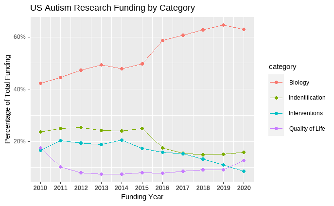

Figure 2. Data from
$$Interagency Autism Coordination Committee$$
(https://iacc.hhs.gov/funding/data/)

## 6.6 Physical and Mental Health

- Health and Well-being: Autistic adults experience higher rates of mental health issues, physical health disparities, and substantially elevated suicide risk
  $$<https://www.nature.com/articles/s41583-021-00463-7>, <https://pubmed.ncbi.nlm.nih.gov/33407027/>$$
  .
- Social Isolation: Negative social experiences can lead to self-isolation, exacerbating feelings of loneliness and exclusion [@Loomes2017]

Across a variety of health domains, autistic people fare worse [@LodiSmith2021, @LodiSmith2021a]. Additionally, we are exposed to risks that are not of primary concern for most people [@Muskens2017]. These include autoimmune dysregulation of many kinds, autonomic dysregulation, connective tissue disorders, gastrointestinal disorders, and many other areas of health concerns. A lack of understanding regarding these differences, coupled with communication barriers and false notions about autism all collude to create barriers to accessing health services and care.

## 6.7 Unemployment

- Employment: Many autistic adults face difficulties finding and maintaining employment due to biases and lack of accommodations. In a study of 254 autistic adults, 77% reported difficulties applying for jobs, and only 16% are in full-time paid work
  $$<https://www.ncbi.nlm.nih.gov/pmc/articles/PMC5215190/>, <https://www.frontiersin.org/articles/10.3389/fpsyg.2021.719827/full>$$
  .

## 6.8 Homelessness

Barriers to entry to the workplace as well as challenges and holding jobs due to ablest attitudes or inflexible policies put us at risk of severe financial strain [@Ohl2017]. This coupled with the possibility of reduced social support all increase our risk of exposure to homelessness. The few studies that attempted to investigate autism in homeless populations suggest that rates of autism in homeless populations is much higher than that observed in the general public, and may be ten times higher [@Churchard2019]. Autistic people additionally face extra barriers in accessing the few services for unhoused people. Environments created with the intention of providing support may be aversive or even harmful for autistic people [@Kargas2019].

## 6.9 Suicide

**ADLs**

When a person applies for Medicaid long-term care services in Oregon, we look at how much help they need to perform Activities of Daily Living. Because funding is limited, we use this information (called a service priority level) to decide who is eligible for services. Activities of Daily Living are the basic personal activities all of us need to do that are essential for health and safety. These activities are defined in OAR 411-015-0006 https://www.oregon.gov/odhs/aging-disability-services/pages/adl.aspx

**Alexithymia**

Alexithymia is the inability for someone to recognize, identify, and describe feelings or emotions. It is sometimes referred to as emotional blindness. https://www.health.com/alexithymia-8361963

**Asperger’s Syndrome**

Asperger’s syndrome (sometimes called high-functioning autism) is part of a wide diagnosis called autism spectrum disorder (ASD). Since 2013, Asperger’s syndrome is replaced by the broader diagnosis of ASD within the Diagnostic and Statistical Manual of Mental Disorders (DSM-5) revised criteria. https://my.clevelandclinic.org/health/diseases/6436-asperger-syndrome

**Co-Occurring Conditions**

The preferred term in the autistic community as a replacement for “comorbid” for conditions, traits, and behaviors that are commonly found along with autism.

**Double Empathy**

Double empathy refers to how: 1. It is easier to understand the mindset of people who are similar to you 2. It is more difficult to understand the mindset of those who are different from you This concept was specifically developed by the autistic autism researcher Damian Milton to explain how autistics and neurotypicals empathize with each other. It explains how allistics (non-autistics) struggle to understand the lived experiences of autistics and autistics struggle to understand the lived experiences of allistics. Likewise, autistics are better at understanding other autistics and allistics are better at understanding other allistics. https://embrace-autism.com/autism-and-the-double-empathy-problem/

**Dyslexia**

Dyslexia is a specific learning difficulty which primarily affects reading and writing skills. However, it does not only affect these skills. Dyslexia is actually about information processing. Dyslexic people may have difficulty processing and remembering information they see and hear, which can affect learning and the acquisition of literacy skills. Dyslexia can also impact on other areas such as organisational skills. It is important to remember that there are positives to thinking differently. Many dyslexic people show strengths in areas such as reasoning and in visual and creative fields. https://www.bdadyslexia.org.uk/dyslexia/about-dyslexia/what-is-dyslexia

**Dyspraxia**

Dyspraxia is a term that refers to lifelong trouble with movement and coordination. It’s not a formal diagnosis. But you may still hear people use this term, especially in the U.K. The formal diagnosis is developmental coordination disorder (DCD). https://www.understood.org/en/articles/understanding-dyspraxia

**fMRI**

Functional MRI is a type of MRI scan that can show which areas of your brain are most active. Tracking and comparing that activity to what you were doing at the time can help “map” your brain activity. It’s most often used for planning surgery or similar procedures in the brain. https://my.clevelandclinic.org/health/diagnostics/25034-functional-mri-fmri

**Gender identity**

One’s innermost concept of self as male, female, a blend of both or neither – how individuals perceive themselves and what they call themselves. One’s gender identity can be the same or different from their sex assigned at birth. https://www.hrc.org/resources/sexual-orientation-and-gender-identity-terminology-and-definitions

**Genome**

The genome is the entire set of DNA instructions found in a cell. In humans, the genome consists of 23 pairs of chromosomes located in the cell’s nucleus, as well as a small chromosome in the cell’s mitochondria. A genome contains all the information needed for an individual to develop and function. https://www.genome.gov/genetics-glossary/Genome

**Health Share Oregon**

One of Oregon’s Community Care Organizations (CCO) for OHP. https://www.healthshareoregon.org/

**I/DD**

Oregon Department of Human Services: Intellectual and Developmental Disabilities.

**Letter of Medical Necessity**

A Letter of Medical Necessity (LMN) is the written explanation from the treating physician describing the medical need for services, equipment, or supplies to assist the claimant in the treatment, care, or relief of their accepted work-related illness(es). https://www.dol.gov/sites/dolgov/files/OWCP/energy/regs/compliance/Outreach/Outreach_Presentation/lmn_mba06222022.pdf

**Neurodivergent**

See Appendix 4: Neurodiversity and Neurodivergence

**Neurodiversity**

See Appendix 4: Neurodiversity and Neurodivergence

**Non-Speaking**

When an autistic person doesn’t speak, it’s known as nonspeaking autism. You may also see it described as nonverbal autism. However, the term nonverbal isn’t completely accurate, since it means “without words. Even if an autistic person is nonspeaking, they may still use words in other ways (such as in writing). They may also understand the words that are spoken to them or that they overhear. https://www.healthline.com/health/autism/nonverbal-autism

**OCD**

Obsessive-compulsive disorder (OCD) is a disorder in which people have recurring, unwanted thoughts, ideas or sensations (obsessions). To get rid of the thoughts, they feel driven to do something repetitively (compulsions). The repetitive behaviors, such as hand washing/cleaning, checking on things, and mental acts like (counting) or other activities, can significantly interfere with a person’s daily activities and social interactions. https://www.psychiatry.org/patients-families/obsessive-compulsive-disorder/what-is-obsessive-compulsive-disorder

**ODDS**

Oregon Office of Developmental Disabilities Services

**OHP**

Oregon Health Plan: Oregon Medicaid

**Services Cliff**

Many high school students on the autism spectrum get help through special education – most commonly including speech-language therapy, service coordination/case management, behavior management, and special transportation. Each student has a team that works with the student and family to decide which services are needed to prepare him or her for young adulthood, and federal law requires schools to offer the necessary services. Sounds like a good plan for how to help vulnerable youth through a challenging period of life. But then, following the last day of high school, the legal mandate for help suddenly ends. https://drexel.edu/autismoutcomes/blog/overview/2015/August/falling-off-the-services-cliff/

**Sexual orientation**

An inherent or immutable enduring emotional, romantic or sexual attraction to other people. Note: an individual’s sexual orientation is independent of their gender identity. https://www.hrc.org/resources/sexual-orientation-and-gender-identity-terminology-and-definitions

**Synesthesia**

Synesthesia is when your brain routes sensory information through multiple unrelated senses, causing you to experience more than one sense simultaneously. Some examples include tasting words or linking colors to numbers and letters. It’s not a medical condition, and many people find it useful to help them learn and remember information. https://my.clevelandclinic.org/health/symptoms/24995-synesthesia

**Theory of Mind**

In psychology, theory of mind refers to the capacity to understand other people by ascribing mental states to them. A theory of mind includes the knowledge that others’ beliefs, desires, intentions, emotions, and thoughts may be different from one’s own. Possessing a functional theory of mind is crucial for success in everyday human social interactions. People utilize a theory of mind when analyzing, judging, and inferring others’ behaviors. The discovery and development of theory of mind primarily came from studies done with animals and infants. Factors including drug and alcohol consumption, language development, cognitive delays, age, and culture can affect a person’s capacity to display theory of mind. Having a theory of mind is similar to but not identical with having the capacity for empathy or sympathy. https://en.wikipedia.org/wiki/Theory_of_mind

# 7 Representative Salaries

[output not shown]

[output cut: 33 more lines]

[output not shown]

# 8 Potential Funders

```
##
##
## ## Healthcare
##
##
##
## ### Adventist
##
## - [Sponsorship Request](https://hipaa-submit.jotform.com/221594871753061)
##  - [Community Benefit](https://adventisthealth.org/portland/about-us/community-benefit/)
##
##
## ### Cambia
##
## - [Healthy and Connected Aging](https://www.cambiahealthfoundation.org/focus-areas/healthy-and-connected-aging.html)
##  - [Sponsorship](https://www.cambiahealthfoundation.org/applicant-resources/current-funding-opportunities.html)
##
##
## ### CareOregon
##
## - [Community Giving grants and sponsorships](https://www.careoregon.org/community/community-giving-grants-for-nonprofit-organizations)
##  - [HRSN Services](request.social.determinants@careoregon.org,)
##
##
## ### Central Oregon Health Council
##
## - [Standard Grants](https://cohealthcouncil.org/standard-grants/)
##
##
## ### Health Share
##
## - [Sponsorship](https://www.healthshareoregon.org/about/sponsorship)
##  - [HRSN Services](https://www.healthshareoregon.org/community-partners/hrsn)
##  - [HRSN Services](https://health-share-or.portals.zenginehq.com/program/community-capacity-building/info)
##
##
## ### Kaiser
##
## - [HRSN Services](Laura.J.Howard@kp.org)
##  - [HRSN Services](https://communityhealth-midatlantic.kaiserpermanente.org/improving-communities/grantmaking/)
```

[output cut: 173 more lines]

```
##
##
## ### Fidget Tech
##
## - [Need info](https://www.fidgetech.org/)
##
##
## ### Organization for Autism Research
##
## - [Community Grant Competition](https://researchautism.smapply.org/prog/community_grant/)
##
##
## ### Patient Centered Outcomes Research Organization
##
## - [Need info](https://www.pcori.org/)
```

# 9 Glossary

**ADLs**

When a person applies for Medicaid long-term care services in Oregon, we look at how much help they need to perform Activities of Daily Living. Because funding is limited, we use this information (called a service priority level) to decide who is eligible for services. Activities of Daily Living are the basic personal activities all of us need to do that are essential for health and safety. These activities are defined in OAR 411-015-0006 https://www.oregon.gov/odhs/aging-disability-services/pages/adl.aspx

**Alexithymia**

Alexithymia is the inability for someone to recognize, identify, and describe feelings or emotions. It is sometimes referred to as emotional blindness. https://www.health.com/alexithymia-8361963

**Asperger’s Syndrome**

Asperger’s syndrome (sometimes called high-functioning autism) is part of a wide diagnosis called autism spectrum disorder (ASD). Since 2013, Asperger’s syndrome is replaced by the broader diagnosis of ASD within the Diagnostic and Statistical Manual of Mental Disorders (DSM-5) revised criteria. https://my.clevelandclinic.org/health/diseases/6436-asperger-syndrome

**Co-Occurring Conditions**

The preferred term in the autistic community as a replacement for “comorbid” for conditions, traits, and behaviors that are commonly found along with autism.

**Double Empathy**

Double empathy refers to how: 1. It is easier to understand the mindset of people who are similar to you 2. It is more difficult to understand the mindset of those who are different from you This concept was specifically developed by the autistic autism researcher Damian Milton to explain how autistics and neurotypicals empathize with each other. It explains how allistics (non-autistics) struggle to understand the lived experiences of autistics and autistics struggle to understand the lived experiences of allistics. Likewise, autistics are better at understanding other autistics and allistics are better at understanding other allistics. https://embrace-autism.com/autism-and-the-double-empathy-problem/

**Dyslexia**

Dyslexia is a specific learning difficulty which primarily affects reading and writing skills. However, it does not only affect these skills. Dyslexia is actually about information processing. Dyslexic people may have difficulty processing and remembering information they see and hear, which can affect learning and the acquisition of literacy skills. Dyslexia can also impact on other areas such as organisational skills. It is important to remember that there are positives to thinking differently. Many dyslexic people show strengths in areas such as reasoning and in visual and creative fields. https://www.bdadyslexia.org.uk/dyslexia/about-dyslexia/what-is-dyslexia

**Dyspraxia**

Dyspraxia is a term that refers to lifelong trouble with movement and coordination. It’s not a formal diagnosis. But you may still hear people use this term, especially in the U.K. The formal diagnosis is developmental coordination disorder (DCD). https://www.understood.org/en/articles/understanding-dyspraxia

**fMRI**

Functional MRI is a type of MRI scan that can show which areas of your brain are most active. Tracking and comparing that activity to what you were doing at the time can help “map” your brain activity. It’s most often used for planning surgery or similar procedures in the brain. https://my.clevelandclinic.org/health/diagnostics/25034-functional-mri-fmri

**Gender identity**

One’s innermost concept of self as male, female, a blend of both or neither – how individuals perceive themselves and what they call themselves. One’s gender identity can be the same or different from their sex assigned at birth. https://www.hrc.org/resources/sexual-orientation-and-gender-identity-terminology-and-definitions

**Genome**

The genome is the entire set of DNA instructions found in a cell. In humans, the genome consists of 23 pairs of chromosomes located in the cell’s nucleus, as well as a small chromosome in the cell’s mitochondria. A genome contains all the information needed for an individual to develop and function. https://www.genome.gov/genetics-glossary/Genome

**Health Share Oregon**

One of Oregon’s Community Care Organizations (CCO) for OHP. https://www.healthshareoregon.org/

**I/DD**

Oregon Department of Human Services: Intellectual and Developmental Disabilities.

**Letter of Medical Necessity**

A Letter of Medical Necessity (LMN) is the written explanation from the treating physician describing the medical need for services, equipment, or supplies to assist the claimant in the treatment, care, or relief of their accepted work-related illness(es). https://www.dol.gov/sites/dolgov/files/OWCP/energy/regs/compliance/Outreach/Outreach_Presentation/lmn_mba06222022.pdf

**Neurodivergent**

See Appendix 4: Neurodiversity and Neurodivergence

**Neurodiversity**

See Appendix 4: Neurodiversity and Neurodivergence

**Non-Speaking**

When an autistic person doesn’t speak, it’s known as nonspeaking autism. You may also see it described as nonverbal autism. However, the term nonverbal isn’t completely accurate, since it means “without words. Even if an autistic person is nonspeaking, they may still use words in other ways (such as in writing). They may also understand the words that are spoken to them or that they overhear. https://www.healthline.com/health/autism/nonverbal-autism

**OCD**

Obsessive-compulsive disorder (OCD) is a disorder in which people have recurring, unwanted thoughts, ideas or sensations (obsessions). To get rid of the thoughts, they feel driven to do something repetitively (compulsions). The repetitive behaviors, such as hand washing/cleaning, checking on things, and mental acts like (counting) or other activities, can significantly interfere with a person’s daily activities and social interactions. https://www.psychiatry.org/patients-families/obsessive-compulsive-disorder/what-is-obsessive-compulsive-disorder

**ODDS**

Oregon Office of Developmental Disabilities Services

**OHP**

Oregon Health Plan: Oregon Medicaid

**Services Cliff**

Many high school students on the autism spectrum get help through special education – most commonly including speech-language therapy, service coordination/case management, behavior management, and special transportation. Each student has a team that works with the student and family to decide which services are needed to prepare him or her for young adulthood, and federal law requires schools to offer the necessary services. Sounds like a good plan for how to help vulnerable youth through a challenging period of life. But then, following the last day of high school, the legal mandate for help suddenly ends. https://drexel.edu/autismoutcomes/blog/overview/2015/August/falling-off-the-services-cliff/

**Sexual orientation**

An inherent or immutable enduring emotional, romantic or sexual attraction to other people. Note: an individual’s sexual orientation is independent of their gender identity. https://www.hrc.org/resources/sexual-orientation-and-gender-identity-terminology-and-definitions

**Synesthesia**

Synesthesia is when your brain routes sensory information through multiple unrelated senses, causing you to experience more than one sense simultaneously. Some examples include tasting words or linking colors to numbers and letters. It’s not a medical condition, and many people find it useful to help them learn and remember information. https://my.clevelandclinic.org/health/symptoms/24995-synesthesia

**Theory of Mind**

In psychology, theory of mind refers to the capacity to understand other people by ascribing mental states to them. A theory of mind includes the knowledge that others’ beliefs, desires, intentions, emotions, and thoughts may be different from one’s own. Possessing a functional theory of mind is crucial for success in everyday human social interactions. People utilize a theory of mind when analyzing, judging, and inferring others’ behaviors. The discovery and development of theory of mind primarily came from studies done with animals and infants. Factors including drug and alcohol consumption, language development, cognitive delays, age, and culture can affect a person’s capacity to display theory of mind. Having a theory of mind is similar to but not identical with having the capacity for empathy or sympathy. https://en.wikipedia.org/wiki/Theory_of_mind